# Netflix

## Netflix casestudy

```python
import numpy as np
import pandas as pd
```

```python
df=pd.read_csv('netflix.csv')
```

```python
df.head(2)
```

|  | show_id | type | title | director | cast | country | date_added | release_year | rating | duration | listed_in | description |
| --- | --- | --- | --- | --- | --- | --- | --- | --- | --- | --- | --- | --- |
| 0 | s1 | Movie | Dick Johnson Is Dead | Kirsten Johnson | NaN | United States | September 25, 2021 | 2020 | PG-13 | 90 min | Documentaries | As her father nears the end of his life, filmm... |
| 1 | s2 | TV Show | Blood & Water | NaN | Ama Qamata, Khosi Ngema, Gail Mabalane, Thaban... | South Africa | September 24, 2021 | 2021 | TV-MA | 2 Seasons | International TV Shows, TV Dramas, TV Mysteries | After crossing paths at a party, a Cape Town t... |

```python
df.tail(1)
```

|  | show_id | type | title | director | cast | country | date_added | release_year | rating | duration | listed_in | description |
| --- | --- | --- | --- | --- | --- | --- | --- | --- | --- | --- | --- | --- |
| 8806 | s8807 | Movie | Zubaan | Mozez Singh | Vicky Kaushal, Sarah-Jane Dias, Raaghav Chanan... | India | March 2, 2019 | 2015 | TV-14 | 111 min | Dramas, International Movies, Music & Musicals | A scrappy but poor boy worms his way into a ty... |

## Q1. Defining Problem Statement and Analysing basic metrics

**What we want to do with the given dataset**

1. Analyze the data to generate insights on the types of shows and movies Netflix should produce.
2. Identify strategies for growing Netflix's business in different countries.
3. Provide recommendations for tailoring content based on regional preferences and demand.

```python
df.head(3)
# I can see many missing data
#Duration is not correct some are given as Seasons
```

|  | show_id | type | title | director | cast | country | date_added | release_year | rating | duration | listed_in | description |
| --- | --- | --- | --- | --- | --- | --- | --- | --- | --- | --- | --- | --- |
| 0 | s1 | Movie | Dick Johnson Is Dead | Kirsten Johnson | NaN | United States | September 25, 2021 | 2020 | PG-13 | 90 min | Documentaries | As her father nears the end of his life, filmm... |
| 1 | s2 | TV Show | Blood & Water | NaN | Ama Qamata, Khosi Ngema, Gail Mabalane, Thaban... | South Africa | September 24, 2021 | 2021 | TV-MA | 2 Seasons | International TV Shows, TV Dramas, TV Mysteries | After crossing paths at a party, a Cape Town t... |
| 2 | s3 | TV Show | Ganglands | Julien Leclercq | Sami Bouajila, Tracy Gotoas, Samuel Jouy, Nabi... | NaN | September 24, 2021 | 2021 | TV-MA | 1 Season | Crime TV Shows, International TV Shows, TV Act... | To protect his family from a powerful drug lor... |

```python
df.shape
```

```
(8807, 12)
```

```python
df.info()
#Below is the info like total rows=0 to 8806 and cloumns 12
```

```
<class 'pandas.core.frame.DataFrame'>
RangeIndex: 8807 entries, 0 to 8806
Data columns (total 12 columns):
 #   Column        Non-Null Count  Dtype
---  ------        --------------  -----
 0   show_id       8807 non-null   object
 1   type          8807 non-null   object
 2   title         8807 non-null   object
 3   director      6173 non-null   object
 4   cast          7982 non-null   object
 5   country       7976 non-null   object
 6   date_added    8797 non-null   object
 7   release_year  8807 non-null   int64
 8   rating        8803 non-null   object
 9   duration      8804 non-null   object
 10  listed_in     8807 non-null   object
 11  description   8807 non-null   object
dtypes: int64(1), object(11)
memory usage: 825.8+ KB
```

```python
df.nunique()
# we can observe the the unique values present in each column
# Main thing to observe is their are 2 "TYPES" those are movies and TV shows
```

|  | 0 |
| --- | --- |
| show_id | 8807 |
| type | 2 |
| title | 8807 |
| director | 4528 |
| cast | 7692 |
| country | 748 |
| date_added | 1767 |
| release_year | 74 |
| rating | 17 |
| duration | 220 |
| listed_in | 514 |
| description | 8775 |

**dtype:** int64

```python
df[df.duplicated()]
#we can observe as a whole their are no duplicates
#But if we take each column we can find duplicate
```

|  | show_id | type | title | director | cast | country | date_added | release_year | rating | duration | listed_in | description |
| --- | --- | --- | --- | --- | --- | --- | --- | --- | --- | --- | --- | --- |

```python
#null values
df.isnull().sum()
# what i observe is max null values are in director column
''''''''''
 we have to make sure that director names are their because many of the audience whach the film or tvshow because they
 might like the director if they scearch for movies on the base of director they might get a bad experience

 ''''''''''
```

|  | 0 |
| --- | --- |
| show_id | 0 |
| type | 0 |
| title | 0 |
| director | 2634 |
| cast | 825 |
| country | 831 |
| date_added | 10 |
| release_year | 0 |
| rating | 4 |
| duration | 3 |
| listed_in | 0 |
| description | 0 |

**dtype:** int64

After basic analisis what i observe is

1. Their are 8807 entries ans 12 columns 2.Their are null vaues in Director,rating,cast,country,date added columns

which can cause a negetive side like : if we take situations were directors are missing

- Many viewers choose to watch content based on their preference for a particular director.
- If director names are missing, viewers may have a negative experience when searching for content.
- Properly displaying director names helps to meet the expectations of audiences who value directors when selecting movies or shows.

This can be case for cast

## Q2. Observations on the shape of data, data types of all the attributes, conversion of categorical attributes to 'category' (If required), missing value detection, statistical summary

```python
df.info()
```

```
<class 'pandas.core.frame.DataFrame'>
RangeIndex: 8807 entries, 0 to 8806
Data columns (total 12 columns):
 #   Column        Non-Null Count  Dtype
---  ------        --------------  -----
 0   show_id       8807 non-null   object
 1   type          8807 non-null   object
 2   title         8807 non-null   object
 3   director      6173 non-null   object
 4   cast          7982 non-null   object
 5   country       7976 non-null   object
 6   date_added    8797 non-null   object
 7   release_year  8807 non-null   int64
 8   rating        8803 non-null   object
 9   duration      8804 non-null   object
 10  listed_in     8807 non-null   object
 11  description   8807 non-null   object
dtypes: int64(1), object(11)
memory usage: 825.8+ KB
```

```python
df.nunique()
```

|  | 0 |
| --- | --- |
| show_id | 8807 |
| type | 2 |
| title | 8807 |
| director | 4528 |
| cast | 7692 |
| country | 748 |
| date_added | 1767 |
| release_year | 74 |
| rating | 17 |
| duration | 220 |
| listed_in | 514 |
| description | 8775 |

**dtype:** int64

```python
df.nunique().index
```

```
Index(['show_id', 'type', 'title', 'director', 'cast', 'country', 'date_added',
       'release_year', 'rating', 'duration', 'listed_in', 'description'],
      dtype='object')
```

```python
#we can see that their are missing values below for columns.
df[df['director'].isnull()]
df[df['cast'].isnull()]
df[df['country'].isnull()]
df[df['date_added'].isnull()]
df[df['rating'].isnull()]
df[df['duration'].isnull()]
```

|  | show_id | type | title | director | cast | country | date_added | release_year | rating | duration | listed_in | description |
| --- | --- | --- | --- | --- | --- | --- | --- | --- | --- | --- | --- | --- |
| 5541 | s5542 | Movie | Louis C.K. 2017 | Louis C.K. | Louis C.K. | United States | April 4, 2017 | 2017 | 74 min | NaN | Movies | Louis C.K. muses on religion, eternal love, gi... |
| 5794 | s5795 | Movie | Louis C.K.: Hilarious | Louis C.K. | Louis C.K. | United States | September 16, 2016 | 2010 | 84 min | NaN | Movies | Emmy-winning comedy writer Louis C.K. brings h... |
| 5813 | s5814 | Movie | Louis C.K.: Live at the Comedy Store | Louis C.K. | Louis C.K. | United States | August 15, 2016 | 2015 | 66 min | NaN | Movies | The comic puts his trademark hilarious/thought... |

```python
# Iam changing the type column from object to category
df['type']=df['type'].astype('category')
```

```python
df.info()
```

```
<class 'pandas.core.frame.DataFrame'>
RangeIndex: 8807 entries, 0 to 8806
Data columns (total 12 columns):
 #   Column        Non-Null Count  Dtype
---  ------        --------------  -----
 0   show_id       8807 non-null   object
 1   type          8807 non-null   category
 2   title         8807 non-null   object
 3   director      6173 non-null   object
 4   cast          7982 non-null   object
 5   country       7976 non-null   object
 6   date_added    8797 non-null   object
 7   release_year  8807 non-null   int64
 8   rating        8803 non-null   object
 9   duration      8804 non-null   object
 10  listed_in     8807 non-null   object
 11  description   8807 non-null   object
dtypes: category(1), int64(1), object(10)
memory usage: 765.7+ KB
```

```python
# i wolud like to mention Missing insted of NaN
df.fillna('Missing',inplace=True)
```

```python
# Different type of statistical for numerical ,categorical columns
df['show_id'].describe()
df['type'].describe()
df['title'].describe()
df['director'].describe()
df['cast'].describe()
df['country'].describe()
df['date_added'].describe()
df['rating'].describe()
df['duration'].describe()
df['listed_in'].describe()
df['description'].describe()
df['release_year'].describe()
```

|  | release_year |
| --- | --- |
| count | 8807.000000 |
| mean | 2014.180198 |
| std | 8.819312 |
| min | 1925.000000 |
| 25% | 2013.000000 |
| 50% | 2017.000000 |
| 75% | 2019.000000 |
| max | 2021.000000 |

Let us take some statistical info to analyse further

```python
#Type their are two and on the top is movies with 6131
df['type'].describe()
```

|  | type |
| --- | --- |
| count | 8807 |
| unique | 2 |
| top | Movie |
| freq | 6131 |

**dtype:** object

```python
#director their are 4528 directors and Rajiv Chilaka has directed more number or films
df['director'].describe()
```

|  | director |
| --- | --- |
| count | 6173 |
| unique | 4528 |
| top | Rajiv Chilaka |
| freq | 19 |

**dtype:** object

```python
#Countries their are 748 unique countries where US is on the top movies and TV.show produced countries
df['country'].describe()
```

|  | country |
| --- | --- |
| count | 7976 |
| unique | 748 |
| top | United States |
| freq | 2818 |

**dtype:** object

```python
#max united states
df['country'].value_counts(ascending=False)
```

| country | count |
| --- | --- |
| United States | 2818 |
| India | 972 |
| United Kingdom | 419 |
| Japan | 245 |
| South Korea | 199 |
| ... | ... |
| Romania, Bulgaria, Hungary | 1 |
| Uruguay, Guatemala | 1 |
| France, Senegal, Belgium | 1 |
| Mexico, United States, Spain, Colombia | 1 |
| United Arab Emirates, Jordan | 1 |

748 rows × 1 columns

**dtype:** int64

```python
#Duration as we can see it is writen season 1
df['duration'].describe()
df[df['duration']=='1 Season']
df[df['title']=='Blood & Water']
df['duration'].unique()
'''''
we can see that their are many unique values for duration but in this column the value 1 season is highest frequency this needs
to be changed as we have to give the correct duration so to that the viewer can have a idea how much time that the he/she can take out to
whach this

'''''
```

```
array(['90 min', '2 Seasons', '1 Season', '91 min', '125 min',
       '9 Seasons', '104 min', '127 min', '4 Seasons', '67 min', '94 min',
       '5 Seasons', '161 min', '61 min', '166 min', '147 min', '103 min',
       '97 min', '106 min', '111 min', '3 Seasons', '110 min', '105 min',
       '96 min', '124 min', '116 min', '98 min', '23 min', '115 min',
       '122 min', '99 min', '88 min', '100 min', '6 Seasons', '102 min',
       '93 min', '95 min', '85 min', '83 min', '113 min', '13 min',
       '182 min', '48 min', '145 min', '87 min', '92 min', '80 min',
       '117 min', '128 min', '119 min', '143 min', '114 min', '118 min',
       '108 min', '63 min', '121 min', '142 min', '154 min', '120 min',
       '82 min', '109 min', '101 min', '86 min', '229 min', '76 min',
       '89 min', '156 min', '112 min', '107 min', '129 min', '135 min',
       '136 min', '165 min', '150 min', '133 min', '70 min', '84 min',
       '140 min', '78 min', '7 Seasons', '64 min', '59 min', '139 min',
       '69 min', '148 min', '189 min', '141 min', '130 min', '138 min',
       '81 min', '132 min', '10 Seasons', '123 min', '65 min', '68 min',
       '66 min', '62 min', '74 min', '131 min', '39 min', '46 min',
       '38 min', '8 Seasons', '17 Seasons', '126 min', '155 min',
       '159 min', '137 min', '12 min', '273 min', '36 min', '34 min',
       '77 min', '60 min', '49 min', '58 min', '72 min', '204 min',
       '212 min', '25 min', '73 min', '29 min', '47 min', '32 min',
       '35 min', '71 min', '149 min', '33 min', '15 min', '54 min',
       '224 min', '162 min', '37 min', '75 min', '79 min', '55 min',
       '158 min', '164 min', '173 min', '181 min', '185 min', '21 min',
       '24 min', '51 min', '151 min', '42 min', '22 min', '134 min',
       '177 min', '13 Seasons', '52 min', '14 min', '53 min', '8 min',
       '57 min', '28 min', '50 min', '9 min', '26 min', '45 min',
       '171 min', '27 min', '44 min', '146 min', '20 min', '157 min',
       '17 min', '203 min', '41 min', '30 min', '194 min', '15 Seasons',
       '233 min', '237 min', '230 min', '195 min', '253 min', '152 min',
       '190 min', '160 min', '208 min', '180 min', '144 min', '5 min',
       '174 min', '170 min', '192 min', '209 min', '187 min', '172 min',
       '16 min', '186 min', '11 min', '193 min', '176 min', '56 min',
       '169 min', '40 min', '10 min', '3 min', '168 min', '312 min',
       '153 min', '214 min', '31 min', '163 min', '19 min', '12 Seasons',
       nan, '179 min', '11 Seasons', '43 min', '200 min', '196 min',
       '167 min', '178 min', '228 min', '18 min', '205 min', '201 min',
       '191 min'], dtype=object)
```

```python
#WE can see the count of relesedate ,mean etc
df['release_year'].describe()
```

|  | release_year |
| --- | --- |
| count | 8807.000000 |
| mean | 2014.180198 |
| std | 8.819312 |
| min | 1925.000000 |
| 25% | 2013.000000 |
| 50% | 2017.000000 |
| 75% | 2019.000000 |
| max | 2021.000000 |

**dtype:** float64

## Q3. Non-Graphical Analysis: Value counts and unique attributes

I have done some analysis above that comes under this .

```python
df.head(1)
```

|  | show_id | type | title | director | cast | country | date_added | release_year | rating | duration | listed_in | description |
| --- | --- | --- | --- | --- | --- | --- | --- | --- | --- | --- | --- | --- |
| 0 | s1 | Movie | Dick Johnson Is Dead | Kirsten Johnson | NaN | United States | September 25, 2021 | 2020 | PG-13 | 90 min | Documentaries | As her father nears the end of his life, filmm... |

```python
# the below lines tell me the categorical data to understand the distribution of values.
df['show_id'].value_counts()
df['type'].value_counts()
df['title'].value_counts()
df['director'].value_counts()
df['cast'].value_counts()
df['country'].value_counts()
df['date_added'].value_counts()
df['rating'].value_counts()
df['duration'].value_counts()
df['listed_in'].value_counts()
df['description'].value_counts()
df['release_year'].value_counts()
```

| release_year | count |
| --- | --- |
| 2018 | 1147 |
| 2017 | 1032 |
| 2019 | 1030 |
| 2020 | 953 |
| 2016 | 902 |
| ... | ... |
| 1959 | 1 |
| 1925 | 1 |
| 1961 | 1 |
| 1947 | 1 |
| 1966 | 1 |

74 rows × 1 columns

**dtype:** int64

```python
#Year where max number of movies release 2018
df['release_year'].value_counts(ascending=False)
```

| release_year | count |
| --- | --- |
| 2018 | 1147 |
| 2017 | 1032 |
| 2019 | 1030 |
| 2020 | 953 |
| 2016 | 902 |
| ... | ... |
| 1959 | 1 |
| 1925 | 1 |
| 1961 | 1 |
| 1947 | 1 |
| 1966 | 1 |

74 rows × 1 columns

**dtype:** int64

```python
df['release_year'].describe()
#We can see the metrics below for release_year
```

|  | release_year |
| --- | --- |
| count | 8807.000000 |
| mean | 2014.180198 |
| std | 8.819312 |
| min | 1925.000000 |
| 25% | 2013.000000 |
| 50% | 2017.000000 |
| 75% | 2019.000000 |
| max | 2021.000000 |

**dtype:** float64

```python
#Maximum nunber of movies directed is Rajiv Chilaka
df['director'].value_counts(ascending=False)
```

| director | count |
| --- | --- |
| Rajiv Chilaka | 19 |
| Raúl Campos, Jan Suter | 18 |
| Marcus Raboy | 16 |
| Suhas Kadav | 16 |
| Jay Karas | 14 |
| ... | ... |
| Raymie Muzquiz, Stu Livingston | 1 |
| Joe Menendez | 1 |
| Eric Bross | 1 |
| Will Eisenberg | 1 |
| Mozez Singh | 1 |

4528 rows × 1 columns

**dtype:** int64

```python
df['show_id'].unique()
df['type'].unique()
df['title'].unique()
df['director'].unique()
df['cast'].unique()
df['country'].unique()
df['date_added'].unique()
df['rating'].unique()
df['duration'].unique()
df['listed_in'].unique()
df['description'].unique()
df['release_year'].unique()
```

```
array(['As her father nears the end of his life, filmmaker Kirsten Johnson stages his death in inventive and comical ways to help them both face the inevitable.',
       'After crossing paths at a party, a Cape Town teen sets out to prove whether a private-school swimming star is her sister who was abducted at birth.',
       'To protect his family from a powerful drug lord, skilled thief Mehdi and his expert team of robbers are pulled into a violent and deadly turf war.',
       ...,
       'Looking to survive in a world taken over by zombies, a dorky college student teams with an urban roughneck and a pair of grifter sisters.',
       'Dragged from civilian life, a former superhero must train a new crop of youthful saviors when the military preps for an attack by a familiar villain.',
       "A scrappy but poor boy worms his way into a tycoon's dysfunctional family, while facing his fear of music and the truth about his past."],
      dtype=object)
```

```python
df['rating'].unique()
```

```
array(['PG-13', 'TV-MA', 'PG', 'TV-14', 'TV-PG', 'TV-Y', 'TV-Y7', 'R',
       'TV-G', 'G', 'NC-17', '74 min', '84 min', '66 min', 'NR', nan,
       'TV-Y7-FV', 'UR'], dtype=object)
```

```python
df['director'].unique()
```

```
array(['Kirsten Johnson', nan, 'Julien Leclercq', ..., 'Majid Al Ansari',
       'Peter Hewitt', 'Mozez Singh'], dtype=object)
```

```python
df['date_added'].unique()
```

```
array(['September 25, 2021', 'September 24, 2021', 'September 23, 2021',
       ..., 'December 6, 2018', 'March 9, 2016', 'January 11, 2020'],
      dtype=object)
```

```python
df['duration'].unique()
```

```
array(['90 min', '2 Seasons', '1 Season', '91 min', '125 min',
       '9 Seasons', '104 min', '127 min', '4 Seasons', '67 min', '94 min',
       '5 Seasons', '161 min', '61 min', '166 min', '147 min', '103 min',
       '97 min', '106 min', '111 min', '3 Seasons', '110 min', '105 min',
       '96 min', '124 min', '116 min', '98 min', '23 min', '115 min',
       '122 min', '99 min', '88 min', '100 min', '6 Seasons', '102 min',
       '93 min', '95 min', '85 min', '83 min', '113 min', '13 min',
       '182 min', '48 min', '145 min', '87 min', '92 min', '80 min',
       '117 min', '128 min', '119 min', '143 min', '114 min', '118 min',
       '108 min', '63 min', '121 min', '142 min', '154 min', '120 min',
       '82 min', '109 min', '101 min', '86 min', '229 min', '76 min',
       '89 min', '156 min', '112 min', '107 min', '129 min', '135 min',
       '136 min', '165 min', '150 min', '133 min', '70 min', '84 min',
       '140 min', '78 min', '7 Seasons', '64 min', '59 min', '139 min',
       '69 min', '148 min', '189 min', '141 min', '130 min', '138 min',
       '81 min', '132 min', '10 Seasons', '123 min', '65 min', '68 min',
       '66 min', '62 min', '74 min', '131 min', '39 min', '46 min',
       '38 min', '8 Seasons', '17 Seasons', '126 min', '155 min',
       '159 min', '137 min', '12 min', '273 min', '36 min', '34 min',
       '77 min', '60 min', '49 min', '58 min', '72 min', '204 min',
       '212 min', '25 min', '73 min', '29 min', '47 min', '32 min',
       '35 min', '71 min', '149 min', '33 min', '15 min', '54 min',
       '224 min', '162 min', '37 min', '75 min', '79 min', '55 min',
       '158 min', '164 min', '173 min', '181 min', '185 min', '21 min',
       '24 min', '51 min', '151 min', '42 min', '22 min', '134 min',
       '177 min', '13 Seasons', '52 min', '14 min', '53 min', '8 min',
       '57 min', '28 min', '50 min', '9 min', '26 min', '45 min',
       '171 min', '27 min', '44 min', '146 min', '20 min', '157 min',
       '17 min', '203 min', '41 min', '30 min', '194 min', '15 Seasons',
       '233 min', '237 min', '230 min', '195 min', '253 min', '152 min',
       '190 min', '160 min', '208 min', '180 min', '144 min', '5 min',
       '174 min', '170 min', '192 min', '209 min', '187 min', '172 min',
       '16 min', '186 min', '11 min', '193 min', '176 min', '56 min',
       '169 min', '40 min', '10 min', '3 min', '168 min', '312 min',
       '153 min', '214 min', '31 min', '163 min', '19 min', '12 Seasons',
       nan, '179 min', '11 Seasons', '43 min', '200 min', '196 min',
       '167 min', '178 min', '228 min', '18 min', '205 min', '201 min',
       '191 min'], dtype=object)
```

```python
df.groupby('type')['title'].value_counts()
df['type'].value_counts()
```

| type | count |
| --- | --- |
| Movie | 6131 |
| TV Show | 2676 |

**dtype:** int64

```python
#max number of shows
df[df['type']=='TV Show']['director'].value_counts(ascending=False)
```

| director | count |
| --- | --- |
| Alastair Fothergill | 3 |
| Rob Seidenglanz | 2 |
| Hsu Fu-chun | 2 |
| Iginio Straffi | 2 |
| Shin Won-ho | 2 |
| ... | ... |
| Juliana Vicente | 1 |
| Chang Chin-jung, Chen Rong-hui | 1 |
| Thierry Demaizière, Alban Teurlai | 1 |
| Manolo Caro | 1 |
| Michael Cumming | 1 |

222 rows × 1 columns

**dtype:** int64

```python
# max number of movies
df[df['type']=='Movie']['director'].value_counts(ascending=False)
```

| director | count |
| --- | --- |
| Rajiv Chilaka | 19 |
| Raúl Campos, Jan Suter | 18 |
| Suhas Kadav | 16 |
| Marcus Raboy | 15 |
| Jay Karas | 14 |
| ... | ... |
| Dennis Rovira van Boekholt | 1 |
| Naoto Amazutsumi | 1 |
| Jenny Gage | 1 |
| Kaila York | 1 |
| Mozez Singh | 1 |

4354 rows × 1 columns

**dtype:** int64

```python
df.head()
```

|  | show_id | type | title | director | cast | country | date_added | release_year | rating | duration | listed_in | description |
| --- | --- | --- | --- | --- | --- | --- | --- | --- | --- | --- | --- | --- |
| 0 | s1 | Movie | Dick Johnson Is Dead | Kirsten Johnson | NaN | United States | September 25, 2021 | 2020 | PG-13 | 90 min | Documentaries | As her father nears the end of his life, filmm... |
| 1 | s2 | TV Show | Blood & Water | NaN | Ama Qamata, Khosi Ngema, Gail Mabalane, Thaban... | South Africa | September 24, 2021 | 2021 | TV-MA | 2 Seasons | International TV Shows, TV Dramas, TV Mysteries | After crossing paths at a party, a Cape Town t... |
| 2 | s3 | TV Show | Ganglands | Julien Leclercq | Sami Bouajila, Tracy Gotoas, Samuel Jouy, Nabi... | NaN | September 24, 2021 | 2021 | TV-MA | 1 Season | Crime TV Shows, International TV Shows, TV Act... | To protect his family from a powerful drug lor... |
| 3 | s4 | TV Show | Jailbirds New Orleans | NaN | NaN | NaN | September 24, 2021 | 2021 | TV-MA | 1 Season | Docuseries, Reality TV | Feuds, flirtations and toilet talk go down amo... |
| 4 | s5 | TV Show | Kota Factory | NaN | Mayur More, Jitendra Kumar, Ranjan Raj, Alam K... | India | September 24, 2021 | 2021 | TV-MA | 2 Seasons | International TV Shows, Romantic TV Shows, TV ... | In a city of coaching centers known to train I... |

```python
'''''
We can see that the listed_in is type of contnet we can make into diffrent catigories by split and explode
'''''
df['listed_in']=df['listed_in'].apply(lambda x:x.split(',')).explode(',')
```

```python
'''''
Below are top 5 in the count in the listed_in
'''''
df['listed_in'].value_counts().head()
```

| listed_in | count |
| --- | --- |
| International Movies | 1162 |
| Dramas | 665 |
| Comedies | 540 |
| International TV Shows | 410 |
| TV Dramas | 374 |

**dtype:** int64

```python
data_movies=df[df['type']=='Movie']
data_TVshows=df[df['type']=='TV Show']
```

```python
data_movies['listed_in'].value_counts()
''''
Below i can observe that their are some tv dramas and also all the names with TV we have to check wethere it is related to tv or movies
''''
```

| listed_in | count |
| --- | --- |
| International Movies | 809 |
| Dramas | 468 |
| Comedies | 378 |
| TV Dramas | 285 |
| International TV Shows | 282 |
| ... | ... |
| Documentaries | 4 |
| Cult Movies | 2 |
| Music & Musicals | 1 |
| Classic & Cult TV | 1 |
| Stand-Up Comedy | 1 |

68 rows × 1 columns

**dtype:** int64

```python
data_TVshows['listed_in'].value_counts()
```

| listed_in | count |
| --- | --- |
| International Movies | 353 |
| Dramas | 197 |
| Comedies | 162 |
| International TV Shows | 128 |
| Dramas | 128 |
| ... | ... |
| Spanish-Language TV Shows | 1 |
| Classic & Cult TV | 1 |
| TV Shows | 1 |
| Romantic Movies | 1 |
| LGBTQ Movies | 1 |

67 rows × 1 columns

**dtype:** int64

What i observe in the analysis is :

1. While doing unique i have found some data is the cloumn which is appropriate to the column which needs to be changed or have to replace with some of the other values like missing etc.
2. Maximum of each column like max number of movies and shows are released in 2018 and max number movies is directed by RajivChilaka and the max number show is directed by Alastair Fothergill.
3. In both movies and shows International Movies are comming first because perticular country people are intrested in other country films.

## 4. Visual Analysis - Univariate, Bivariate after pre-processing of the data

Note: Pre-processing involves unnesting of the data in columns like Actor, Director, Country

4.1 For continuous variable(s): Distplot, countplot, histogram for univariate analysis

4.2 For categorical variable(s): Boxplot

4.3 For correlation: Heatmaps, Pairplots

```python
import matplotlib.pyplot as plt
import seaborn as sns
```

```python
df.tail(1)
```

|  | show_id | type | title | director | cast | country | date_added | release_year | rating | duration | listed_in | description |
| --- | --- | --- | --- | --- | --- | --- | --- | --- | --- | --- | --- | --- |
| 8806 | s8807 | Movie | Zubaan | Mozez Singh | Vicky Kaushal, Sarah-Jane Dias, Raaghav Chanan... | India | March 2, 2019 | 2015 | TV-14 | 111 min | Dramas, International Movies, Music & Musicals | A scrappy but poor boy worms his way into a ty... |

Univariate analysis

1. Numerical(date_added,release_year,duration)
2. Ctogarical(type)

```python
df['date_added'].value_counts(ascending=False)
# January 1, 2020 is more added count on total
```

| date_added | count |
| --- | --- |
| January 1, 2020 | 109 |
| November 1, 2019 | 89 |
| March 1, 2018 | 75 |
| December 31, 2019 | 74 |
| October 1, 2018 | 71 |
| ... | ... |
| December 4, 2016 | 1 |
| November 21, 2016 | 1 |
| November 19, 2016 | 1 |
| November 17, 2016 | 1 |
| January 11, 2020 | 1 |

1767 rows × 1 columns

**dtype:** int64

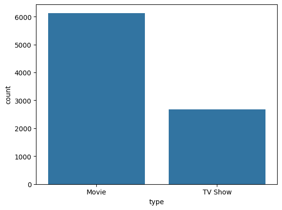

```python
sns.countplot(x='type', data=df, order=df['type'].value_counts(ascending=False).index)
```

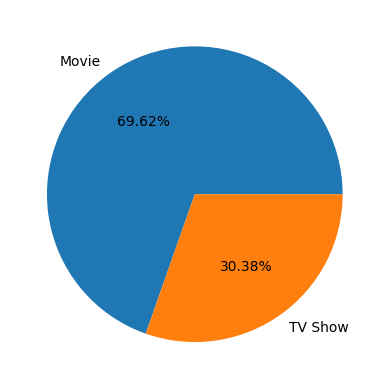

```python
#pie chart on types
data=df['type'].value_counts()
plt.pie(data, labels=data.index, autopct='%.2f%%' )
plt.show()
''''
Here we can see the percentage in a pie chart where movies and TV.Shows
we can see that movie percentage are higher

''''
```

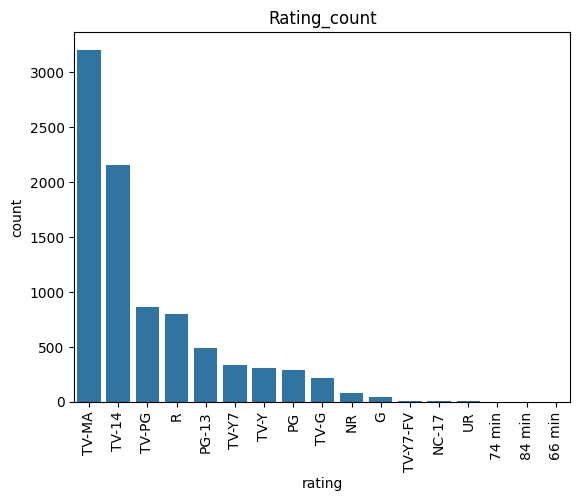

```python
sns.countplot(x='rating', data=df, order=df['rating'].value_counts(ascending=False).index)
plt.xticks(rotation=90)
plt.title('Rating_count')
plt.show()

'''''
Max number of movies are rated as TV-MA
'''''
```

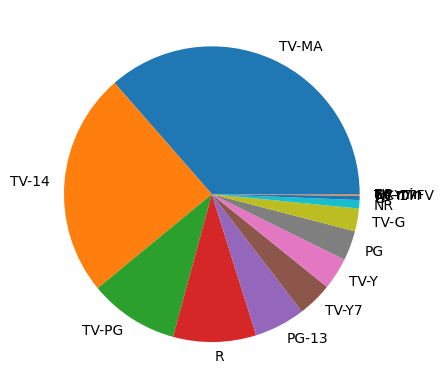

```python
deep=df['rating'].value_counts()
plt.pie(deep,labels=df['rating'].value_counts().index)
plt.show()
```

```python
data_m=data_movies['listed_in'].value_counts().head(5)
```

```python
data_m.head()
```

| listed_in | count |
| --- | --- |
| International Movies | 809 |
| Dramas | 468 |
| Comedies | 378 |
| TV Dramas | 285 |
| International TV Shows | 282 |

**dtype:** int64

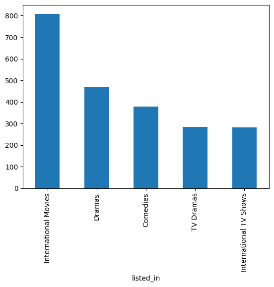

```python
data_movies['listed_in'].value_counts().head(5).plot(kind='bar')
''''
We can observe that in movies International Movies can be recomended
''''
```

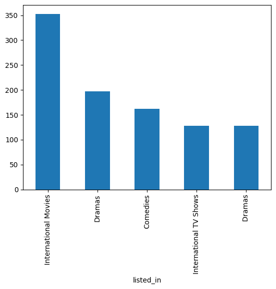

```python
data_TVshows['listed_in'].value_counts().head(5).plot(kind='bar')
''''
We can observe that in movies International Movies can be recomended for shows also
''''
```

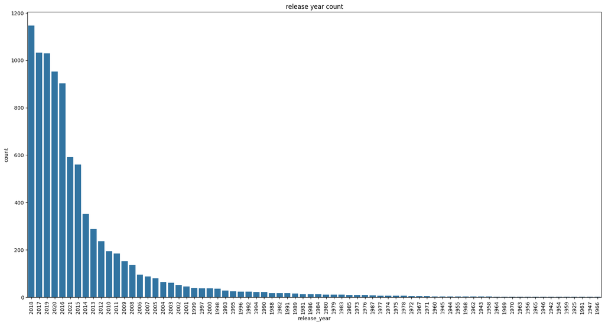

```python
plt.figure(figsize=(20,10))
sns.countplot(x='release_year', data=df, order=df['release_year'].value_counts(ascending=False).index)
plt.xticks(rotation=90)
plt.title('release year count')
plt.show()

'''''
As we can see 2018 max number of movies is produced
'''''
```

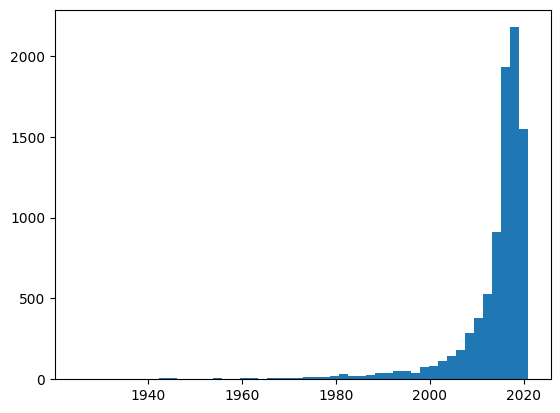

```python
#matplot
plt.hist(df['release_year'],bins=50)
plt.show()

'''''
We can see the histogram view as below
'''''
```

```python
df.tail(1)
```

|  | show_id | type | title | director | cast | country | date_added | release_year | rating | duration | listed_in | description |
| --- | --- | --- | --- | --- | --- | --- | --- | --- | --- | --- | --- | --- |
| 8806 | s8807 | Movie | Zubaan | Mozez Singh | Vicky Kaushal, Sarah-Jane Dias, Raaghav Chanan... | India | March 2, 2019 | 2015 | TV-14 | 111 min | Dramas, International Movies, Music & Musicals | A scrappy but poor boy worms his way into a ty... |

For categorical variable(s): Boxplot

```python
data=df[df['type']=='Movie']
```

```python
data.tail(1)
```

|  | show_id | type | title | director | cast | country | date_added | release_year | rating | duration | listed_in | description |
| --- | --- | --- | --- | --- | --- | --- | --- | --- | --- | --- | --- | --- |
| 8806 | s8807 | Movie | Zubaan | Mozez Singh | Vicky Kaushal, Sarah-Jane Dias, Raaghav Chanan... | India | March 2, 2019 | 2015 | TV-14 | 111 min | Dramas, International Movies, Music & Musicals | A scrappy but poor boy worms his way into a ty... |

```python
data['release_year'].value_counts(ascending=False).head(5)
#max number of movies relased are in 2017
```

| release_year | count |
| --- | --- |
| 2017 | 767 |
| 2018 | 767 |
| 2016 | 658 |
| 2019 | 633 |
| 2020 | 517 |

**dtype:** int64

```python
data_TV_shows=df[df['type']=='TV Show']
```

```python
data_TV_shows.tail(1)
```

|  | show_id | type | title | director | cast | country | date_added | release_year | rating | duration | listed_in | description |
| --- | --- | --- | --- | --- | --- | --- | --- | --- | --- | --- | --- | --- |
| 8803 | s8804 | TV Show | Zombie Dumb | NaN | NaN | NaN | July 1, 2019 | 2018 | TV-Y7 | 2 Seasons | Kids' TV, Korean TV Shows, TV Comedies | While living alone in a spooky town, a young g... |

```python
data_TV_shows['release_year'].value_counts(ascending=False).head(5)
#Max numberof TV_shows realsed in year 2020
```

| release_year | count |
| --- | --- |
| 2020 | 436 |
| 2019 | 397 |
| 2018 | 380 |
| 2021 | 315 |
| 2017 | 265 |

**dtype:** int64

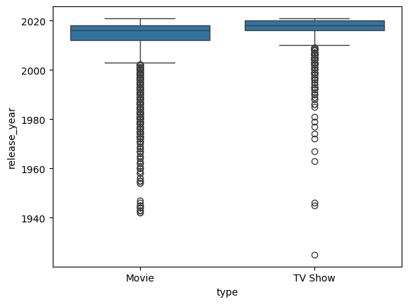

```python
sns.boxplot(x='type',y='release_year',data=df)
```

As we can see more outliers in the above we can set range form (2000, 2022)

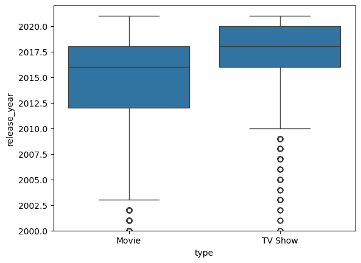

```python
'''''
As far as i can analyse the data taking form 2000 is better
'''''
sns.boxplot(x='type',y='release_year',data=df)
plt.ylim(2000, 2022)
plt.show()
```

```python
df
```

|  | show_id | type | title | director | cast | country | date_added | release_year | rating | duration | listed_in | description |
| --- | --- | --- | --- | --- | --- | --- | --- | --- | --- | --- | --- | --- |
| 0 | s1 | Movie | Dick Johnson Is Dead | Kirsten Johnson | NaN | United States | September 25, 2021 | 2020 | PG-13 | 90 min | Documentaries | As her father nears the end of his life, filmm... |
| 1 | s2 | TV Show | Blood & Water | NaN | Ama Qamata, Khosi Ngema, Gail Mabalane, Thaban... | South Africa | September 24, 2021 | 2021 | TV-MA | 2 Seasons | International TV Shows | After crossing paths at a party, a Cape Town t... |
| 2 | s3 | TV Show | Ganglands | Julien Leclercq | Sami Bouajila, Tracy Gotoas, Samuel Jouy, Nabi... | NaN | September 24, 2021 | 2021 | TV-MA | 1 Season | TV Dramas | To protect his family from a powerful drug lor... |
| 3 | s4 | TV Show | Jailbirds New Orleans | NaN | NaN | NaN | September 24, 2021 | 2021 | TV-MA | 1 Season | TV Mysteries | Feuds, flirtations and toilet talk go down amo... |
| 4 | s5 | TV Show | Kota Factory | NaN | Mayur More, Jitendra Kumar, Ranjan Raj, Alam K... | India | September 24, 2021 | 2021 | TV-MA | 2 Seasons | Crime TV Shows | In a city of coaching centers known to train I... |
| ... | ... | ... | ... | ... | ... | ... | ... | ... | ... | ... | ... | ... |
| 8802 | s8803 | Movie | Zodiac | David Fincher | Mark Ruffalo, Jake Gyllenhaal, Robert Downey J... | United States | November 20, 2019 | 2007 | R | 158 min | Action & Adventure | A political cartoonist, a crime reporter and a... |
| 8803 | s8804 | TV Show | Zombie Dumb | NaN | NaN | NaN | July 1, 2019 | 2018 | TV-Y7 | 2 Seasons | Comedies | While living alone in a spooky town, a young g... |
| 8804 | s8805 | Movie | Zombieland | Ruben Fleischer | Jesse Eisenberg, Woody Harrelson, Emma Stone, ... | United States | November 1, 2019 | 2009 | R | 88 min | Dramas | Looking to survive in a world taken over by zo... |
| 8805 | s8806 | Movie | Zoom | Peter Hewitt | Tim Allen, Courteney Cox, Chevy Chase, Kate Ma... | United States | January 11, 2020 | 2006 | PG | 88 min | Crime TV Shows | Dragged from civilian life, a former superhero... |
| 8806 | s8807 | Movie | Zubaan | Mozez Singh | Vicky Kaushal, Sarah-Jane Dias, Raaghav Chanan... | India | March 2, 2019 | 2015 | TV-14 | 111 min | International TV Shows | A scrappy but poor boy worms his way into a ty... |

8807 rows × 12 columns

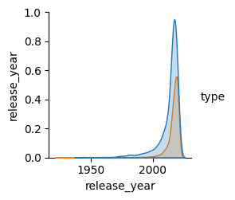

```python
sns.pairplot(data=df,hue='type')
```

```python
df.head(2)
```

|  | show_id | type | title | director | cast | country | date_added | release_year | rating | duration | listed_in | description |
| --- | --- | --- | --- | --- | --- | --- | --- | --- | --- | --- | --- | --- |
| 0 | s1 | Movie | Dick Johnson Is Dead | Kirsten Johnson | NaN | United States | September 25, 2021 | 2020 | PG-13 | 90 min | Documentaries | As her father nears the end of his life, filmm... |
| 1 | s2 | TV Show | Blood & Water | NaN | Ama Qamata, Khosi Ngema, Gail Mabalane, Thaban... | South Africa | September 24, 2021 | 2021 | TV-MA | 2 Seasons | International TV Shows | After crossing paths at a party, a Cape Town t... |

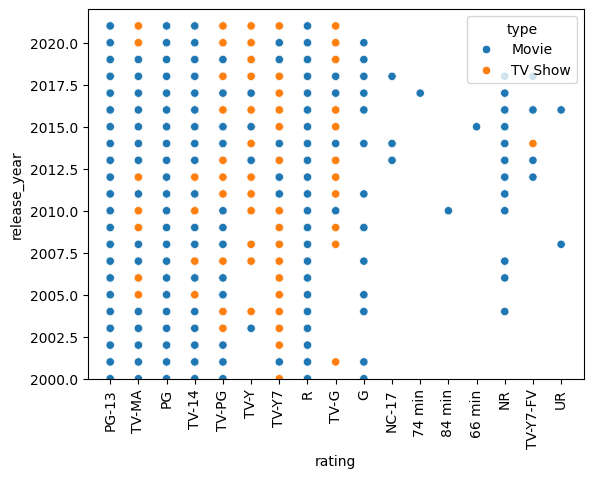

```python
sns.scatterplot(x='rating',y='release_year',hue='type',data=df)
plt.xticks(rotation=90)
plt.ylim(2000, 2022)
plt.show()
```

## 5. Missing Value & Outlier check

I have done the missing Value analisys previously also here also i will do the analysis

```python
df.isnull().sum()
''''
We can see their are dfferent null values
''''
```

|  | 0 |
| --- | --- |
| show_id | 0 |
| type | 0 |
| title | 0 |
| director | 2634 |
| cast | 825 |
| country | 831 |
| date_added | 10 |
| release_year | 0 |
| rating | 4 |
| duration | 3 |
| listed_in | 0 |
| description | 0 |

**dtype:** int64

```python
#I want to fill the null value with missing data so that it will be easy for further changes
df.fillna('Missing_data')
```

[output not shown]

8807 rows × 12 columns

Listed_in should be more refined

Their are many null values in the columns which can be captured and worked upon the retreval form other sources for example director and cast can be retriving for third party sources so that the user will able to find the director and actors

## 6. Insights based on Non-Graphical and Visual Analysis (10 Points)

6.1 Comments on the range of attributes

6.2 Comments on the distribution of the variables and relationship between them

6.3 Comments for each univariate and bivariate plot

```python
df.head(2)
```

|  | show_id | type | title | director | cast | country | date_added | release_year | rating | duration | listed_in | description |
| --- | --- | --- | --- | --- | --- | --- | --- | --- | --- | --- | --- | --- |
| 0 | s1 | Movie | Dick Johnson Is Dead | Kirsten Johnson | NaN | United States | September 25, 2021 | 2020 | PG-13 | 90 min | Documentaries | As her father nears the end of his life, filmm... |
| 1 | s2 | TV Show | Blood & Water | NaN | Ama Qamata, Khosi Ngema, Gail Mabalane, Thaban... | South Africa | September 24, 2021 | 2021 | TV-MA | 2 Seasons | International TV Shows | After crossing paths at a party, a Cape Town t... |

```python
df['release_year'].describe()
''''
We can see the distributions of release_year below
'''
```

|  | release_year |
| --- | --- |
| count | 8807.000000 |
| mean | 2014.180198 |
| std | 8.819312 |
| min | 1925.000000 |
| 25% | 2013.000000 |
| 50% | 2017.000000 |
| 75% | 2019.000000 |
| max | 2021.000000 |

**dtype:** float64

```python
data_movies['duration'].describe()
''''
the recomended duration of time to realse is 90min
'''
```

|  | duration |
| --- | --- |
| count | 6128 |
| unique | 205 |
| top | 90 min |
| freq | 152 |

**dtype:** object

```python
data_movies['country'].describe()
''''
Best country to produce is in United States
'''
```

|  | country |
| --- | --- |
| count | 5691 |
| unique | 651 |
| top | United States |
| freq | 2058 |

**dtype:** object

```python
data_TVshows['country'].describe()
```

|  | country |
| --- | --- |
| count | 2285 |
| unique | 196 |
| top | United States |
| freq | 760 |

**dtype:** object

## I have given the commemnts for univariate and bivariant analisys in the above cells

```python
from google.colab import drive
drive.mount('/content/drive')
```

## 8.Recommendations

1. Fill missing Director and Cast data by pulling from third-party sources or using a default "missing" value.
2. Address missing Country data for better content discoverability in different markets.
3. Standardize duration data by showing actual runtime (hours/minutes for movies) or episode counts for TV shows. This helps users assess time commitment and enhances user satisfaction.
4. Remove duplicates and clean the dataset regularly to ensure data consistency.This improves search accuracy and enhances content recommendations.
5. Revisit reasons behind the decline in production and adjust strategy accordingly.
6. Invest in and promote international content due to its high viewership.
7. Focus on promoting more movies while balancing TV shows to maintain long-term engagement
8. Create region-based categories, collaborate with international production houses, and target marketing efforts in specific regions
9. Integrate third-party APIs (e.g., IMDB) to automatically fill missing Director, Cast, and Country data.
10. Expand international content offerings and highlight it in recommendations.